# Métodos de Simulación

### Grupo 8

- Javier Darna Sequeiros
- Tingyun Wei
- Zihao Hong

*Máster Universitario en Inteligencia Artificial*

## 1. Generación de números y variables aleatorias

Describir el algoritmo de Ziggurat para distribuciones con función de densidad decreciente y compararlo con otros métodos para la generación de valores de la normal.

El **algoritmo de Ziggurat** es un método para generar valores aleatorios a partir de una función de densidad monótona decreciente

- Distribución exponencial
- Distribución normal

Su nombre proviene de unos templos construidos en la antigua Mesopotamia.

[figure not shown]

Este algoritmo está basado el **método de rechazo**:

> 1. Generar puntos aleatorios dentro del rectángulo azul (distribución uniforme)
> 2. Descartar los puntos ($x_{n}$, $y_{n}$) donde $y_{n}$ > $f(x)$
> 3. Tomar la coordenada *x* de cada uno de los puntos restantes

La **eficiencia** de este método suele ser **baja** porque muchos puntos generados acaban siendo descartados.

[figure not shown]

Idea básica del **algoritmo de Ziggurat**:

> Minimizar el área de rechazo con múltiples rectángulos
- FDP decreciente $f(x)$, donde $x ≥ 0$
- Dividir el área debajo de la curva en $n-1$ rectángulos y una cola **con la misma área**.

  > $z_k (k=0,1,...,n-1)$, $z_0=0$.  
  > La cola como los puntos bajo la curva con ordenada inferior a $f(z_{n-1})$.
- Elegir **uniformement**e una de las regiones y aplicamos el **método del rechazo** en esa región.
- Ejemplo: $n=6$ (en práctica n puede alcanzar 64, 128 o 256)
- **Región central** de un rectángulo: la parte que se superpone al rectángulo superior en la dirección de la longitud. El rectángulo superior no tiene región central.

```python
zigguratAlgorithmScheme()
```

[output not shown]

### Inicialización

- Entrada: función de densidad $f$, número de secciones $n$.
- Calculamos por aproximación $z_n$.
- A partir de $z_n$ y el área común de las secciones, calculamos el resto de puntos $z_k$.
- Calculamos $\sigma_k = z_{k-1} / z_k$, que es la fracción del rectángulo k que está enteramente contenida en la curva. $\sigma_1 = 0$

```python
zigguratAlgorithmScheme()
```

[output not shown]

### Algoritmo

[figure not shown]

- En los casos en que el número caiga fuera de la porción central o en la sección de la cola se requieren cálculos adicionales.
- Estos casos son menos probables cuanto mayor sea $n$.
- Para valores de $n$ altos, estos casos son bastante raros, por lo que el algoritmo es muy eficiente.

### Comparación con otros métodos

- **Método de rechazo**: Es más simple pero puede ser muy ineficiente, ya que se pueden llegar a rechazar un gran número de puntos, y para cada uno de ellos hay que calcular $f(x)$, lo cual suele ser costoso.
- **Método de inversión**: El cálculo de la función inversa puede ser muy costoso, al igual que evaluarla.
- **Box-Muller**: Es muy eficiente y ha sido utilizado durante mucho tiempo, pero requiere al menos el cálculo de un logaritmo y una raíz cuadrada para los valores generados.

## Creación de la tabla la distribución normal estándar

Utilizando el algoritmo de Ziggurat obtener una aproximación de la tabla de la tabla de la distribución normal estándar.

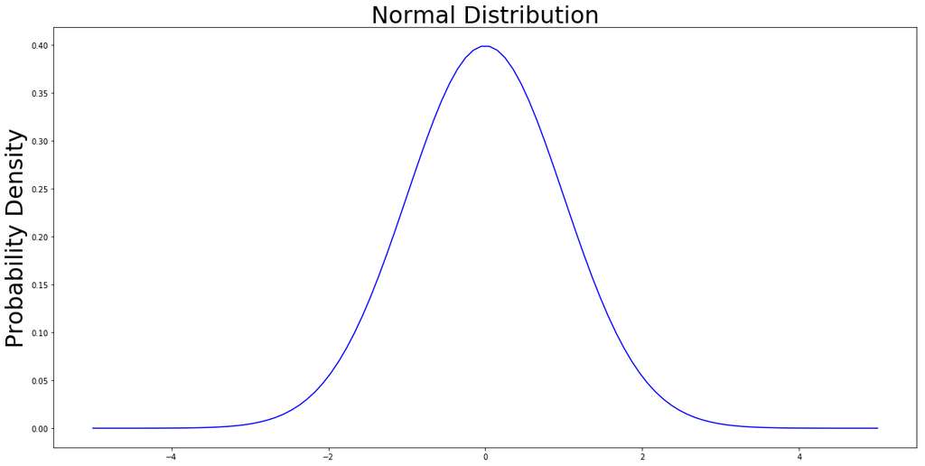

```python
normalDistribution()
```

```python
standard_normal_distribution_table = standardNormalDistributionTable()
standard_normal_distribution_table
```

|  | 0.00 | 0.01 | 0.02 | 0.03 | 0.04 | 0.05 | 0.06 | 0.07 | 0.08 | 0.09 |
| --- | --- | --- | --- | --- | --- | --- | --- | --- | --- | --- |
| 0.0 | 0.5 | 0.504 | 0.508 | 0.512 | 0.516 | 0.5199 | 0.5239 | 0.5279 | 0.5319 | 0.5359 |
| 0.1 | 0.5398 | 0.5438 | 0.5478 | 0.5517 | 0.5557 | 0.5596 | 0.5636 | 0.5675 | 0.5714 | 0.5753 |
| 0.2 | 0.5793 | 0.5832 | 0.5871 | 0.591 | 0.5948 | 0.5987 | 0.6026 | 0.6064 | 0.6103 | 0.6141 |
| 0.3 | 0.6179 | 0.6217 | 0.6255 | 0.6293 | 0.6331 | 0.6368 | 0.6406 | 0.6443 | 0.648 | 0.6517 |
| 0.4 | 0.6554 | 0.6591 | 0.6628 | 0.6664 | 0.67 | 0.6736 | 0.6772 | 0.6808 | 0.6844 | 0.6879 |
| 0.5 | 0.6915 | 0.695 | 0.6985 | 0.7019 | 0.7054 | 0.7088 | 0.7123 | 0.7157 | 0.719 | 0.7224 |
| 0.6 | 0.7257 | 0.7291 | 0.7324 | 0.7357 | 0.7389 | 0.7422 | 0.7454 | 0.7486 | 0.7517 | 0.7549 |
| 0.7 | 0.758 | 0.7611 | 0.7642 | 0.7673 | 0.7704 | 0.7734 | 0.7764 | 0.7794 | 0.7823 | 0.7852 |
| 0.8 | 0.7881 | 0.791 | 0.7939 | 0.7967 | 0.7995 | 0.8023 | 0.8051 | 0.8078 | 0.8106 | 0.8133 |
| 0.9 | 0.8159 | 0.8186 | 0.8212 | 0.8238 | 0.8264 | 0.8289 | 0.8315 | 0.834 | 0.8365 | 0.8389 |

```python
zigguratAlgorithmScheme()
N = 10000
random_numbers = zignor.randn(N)
```

[output not shown]

```python
def zigguratAlgorithmFunction():
    POINT_SIZE = 50
    FIGURE_SIZE = (20, 10)

    counter = {}
    for rand in random_numbers:
        round_rand_number = np.round(rand, 2) # round the number to 2 decimals
        counter[round_rand_number] = counter.get(round_rand_number, 0) + 1

    x_axis = sorted(list(counter.keys()))
    y_axis = list(map(lambda x : counter[x] / N * 100, x_axis))

    domain = np.linspace(-max(x_axis), max(x_axis), N)

    fig, ax = plt.subplots(figsize = (FIGURE_SIZE[0], FIGURE_SIZE[1]));

    ax.plot(x_axis, y_axis, color = 'b')

    ax.plot(domain, list( # domain is the x axis and the rest y axis
        map(
            lambda x: pdf_standard_normal_distribution(x),
            domain
        )
    ), color = 'r', linewidth = 5)

    plt.show()
    return counter
```

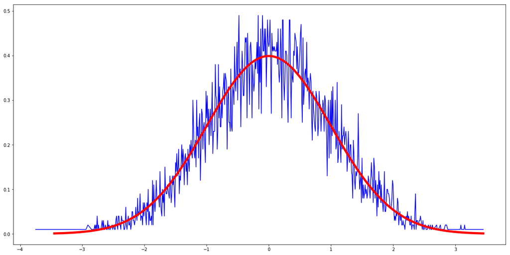

```python
result = zigguratAlgorithmFunction()
```

```python
def zigguratAlgorithmTable(counter):
    standard_normal_table = pd.DataFrame(
        data =[],
        index = np.round(np.arange(0, 1, .1), 2),
        columns = np.round(np.arange(0.00, .1, .01), 2)
    )

    for index in standard_normal_table.index:
        for column in standard_normal_table.columns:
            z = np.round(index+column, 2)
            value = 0
            for k in np.round(np.arange(min( random_numbers ), z, .01), 2):
                if counter.get( k ) is not None:
                    value = value + counter.get(k)
            standard_normal_table.loc[index, column] = value / N

    standard_normal_table.index = standard_normal_table.index.astype(str)
    standard_normal_table.columns = [str(column).ljust(4, '0') for column in standard_normal_table.columns]

    return standard_normal_table
```

```python
standard_normal_ziggurat_table = zigguratAlgorithmTable(result)
standard_normal_ziggurat_table
```

|  | 0.00 | 0.01 | 0.02 | 0.03 | 0.04 | 0.05 | 0.06 | 0.07 | 0.08 | 0.09 |
| --- | --- | --- | --- | --- | --- | --- | --- | --- | --- | --- |
| 0.0 | 0.4952 | 0.4995 | 0.5043 | 0.5082 | 0.5109 | 0.5154 | 0.5195 | 0.5237 | 0.5278 | 0.532 |
| 0.1 | 0.5361 | 0.5402 | 0.5443 | 0.5486 | 0.5524 | 0.557 | 0.5606 | 0.564 | 0.5677 | 0.5723 |
| 0.2 | 0.5764 | 0.579 | 0.5838 | 0.5886 | 0.592 | 0.595 | 0.5985 | 0.6026 | 0.6067 | 0.6107 |
| 0.3 | 0.6138 | 0.6163 | 0.6197 | 0.6245 | 0.6293 | 0.6328 | 0.6354 | 0.6391 | 0.6426 | 0.646 |
| 0.4 | 0.6501 | 0.6541 | 0.6586 | 0.663 | 0.6673 | 0.671 | 0.6752 | 0.6788 | 0.6824 | 0.6862 |
| 0.5 | 0.6903 | 0.6948 | 0.6995 | 0.7025 | 0.705 | 0.7094 | 0.7123 | 0.7155 | 0.7191 | 0.7228 |
| 0.6 | 0.7262 | 0.7305 | 0.7337 | 0.7372 | 0.7406 | 0.7434 | 0.7468 | 0.7504 | 0.7538 | 0.7564 |
| 0.7 | 0.7585 | 0.7617 | 0.7645 | 0.7671 | 0.7695 | 0.7718 | 0.775 | 0.7781 | 0.7809 | 0.7831 |
| 0.8 | 0.7855 | 0.7887 | 0.7916 | 0.7945 | 0.7968 | 0.7995 | 0.8022 | 0.8052 | 0.8081 | 0.8104 |
| 0.9 | 0.8135 | 0.8165 | 0.819 | 0.8212 | 0.8225 | 0.8251 | 0.8281 | 0.8298 | 0.8323 | 0.8353 |

```python
pd.concat([standard_normal_ziggurat_table, standard_normal_distribution_table])
```

|  | 0.00 | 0.01 | 0.02 | 0.03 | 0.04 | 0.05 | 0.06 | 0.07 | 0.08 | 0.09 |
| --- | --- | --- | --- | --- | --- | --- | --- | --- | --- | --- |
| 0.0 | 0.4952 | 0.4995 | 0.5043 | 0.5082 | 0.5109 | 0.5154 | 0.5195 | 0.5237 | 0.5278 | 0.532 |
| 0.1 | 0.5361 | 0.5402 | 0.5443 | 0.5486 | 0.5524 | 0.557 | 0.5606 | 0.564 | 0.5677 | 0.5723 |
| 0.2 | 0.5764 | 0.579 | 0.5838 | 0.5886 | 0.592 | 0.595 | 0.5985 | 0.6026 | 0.6067 | 0.6107 |
| 0.3 | 0.6138 | 0.6163 | 0.6197 | 0.6245 | 0.6293 | 0.6328 | 0.6354 | 0.6391 | 0.6426 | 0.646 |
| 0.4 | 0.6501 | 0.6541 | 0.6586 | 0.663 | 0.6673 | 0.671 | 0.6752 | 0.6788 | 0.6824 | 0.6862 |
| 0.5 | 0.6903 | 0.6948 | 0.6995 | 0.7025 | 0.705 | 0.7094 | 0.7123 | 0.7155 | 0.7191 | 0.7228 |
| 0.6 | 0.7262 | 0.7305 | 0.7337 | 0.7372 | 0.7406 | 0.7434 | 0.7468 | 0.7504 | 0.7538 | 0.7564 |
| 0.7 | 0.7585 | 0.7617 | 0.7645 | 0.7671 | 0.7695 | 0.7718 | 0.775 | 0.7781 | 0.7809 | 0.7831 |
| 0.8 | 0.7855 | 0.7887 | 0.7916 | 0.7945 | 0.7968 | 0.7995 | 0.8022 | 0.8052 | 0.8081 | 0.8104 |
| 0.9 | 0.8135 | 0.8165 | 0.819 | 0.8212 | 0.8225 | 0.8251 | 0.8281 | 0.8298 | 0.8323 | 0.8353 |
| 0.0 | 0.5 | 0.504 | 0.508 | 0.512 | 0.516 | 0.5199 | 0.5239 | 0.5279 | 0.5319 | 0.5359 |
| 0.1 | 0.5398 | 0.5438 | 0.5478 | 0.5517 | 0.5557 | 0.5596 | 0.5636 | 0.5675 | 0.5714 | 0.5753 |
| 0.2 | 0.5793 | 0.5832 | 0.5871 | 0.591 | 0.5948 | 0.5987 | 0.6026 | 0.6064 | 0.6103 | 0.6141 |
| 0.3 | 0.6179 | 0.6217 | 0.6255 | 0.6293 | 0.6331 | 0.6368 | 0.6406 | 0.6443 | 0.648 | 0.6517 |
| 0.4 | 0.6554 | 0.6591 | 0.6628 | 0.6664 | 0.67 | 0.6736 | 0.6772 | 0.6808 | 0.6844 | 0.6879 |
| 0.5 | 0.6915 | 0.695 | 0.6985 | 0.7019 | 0.7054 | 0.7088 | 0.7123 | 0.7157 | 0.719 | 0.7224 |
| 0.6 | 0.7257 | 0.7291 | 0.7324 | 0.7357 | 0.7389 | 0.7422 | 0.7454 | 0.7486 | 0.7517 | 0.7549 |
| 0.7 | 0.758 | 0.7611 | 0.7642 | 0.7673 | 0.7704 | 0.7734 | 0.7764 | 0.7794 | 0.7823 | 0.7852 |
| 0.8 | 0.7881 | 0.791 | 0.7939 | 0.7967 | 0.7995 | 0.8023 | 0.8051 | 0.8078 | 0.8106 | 0.8133 |
| 0.9 | 0.8159 | 0.8186 | 0.8212 | 0.8238 | 0.8264 | 0.8289 | 0.8315 | 0.834 | 0.8365 | 0.8389 |

## Conclusión

- El algoritmo de Ziggurat es una mejora del método de rechazo.
- Es uno de los algoritmos de generación de distribuciones que mejor conserva el equilibrio entre eficiencia y calidad de los números generados.
- Requiere una inicialización que puede ser costosa, pero sólo se requiere hacer una vez por distribución.
- Sólo funciona con funciones estrictamente decrecientes en $[0,+\infty)$ o simétricas.

## Referencias

- Marsaglia, G., & Tsang, W. W. (2000). The ziggurat method for generating random variables. Journal of statistical software, 5(8), 1-7.
- https://towardsdatascience.com/how-to-use-and-create-a-z-table-standard-normal-table-240e21f36e53